# Informe del Taller 92 93 94

Julian Velandia, Julian Albarracín, Tomas Bermudez

2025-06-03

# 1 Descripción

A continuación se presenta el desarrollo del *Taller #3*, en el cuál se solucionan 5 puntos impares multiplos de 3 de las páginas 92, 93 y 94 del libro de Probabilidad de Walpol relacionados con la función de distribución acumulativa para variables Continuas y Discretas.

# 2 Desarrollo

## 2.1 Primer punto

*Enunciado 3.9:* La proporción de personas que responden a cierta encuesta enviada por correo es una variable aleatoria continua X que tiene la siguiente función de densidad:

$$f(x) =
\begin{cases}
\frac{2(x + 2)}{5}, & \text{si } 0 < x < 1, \\
0, & \text{en otro caso}.
\end{cases}$$

1. Demuestre que P(0 < X < 1) = 1.
2. Calcule la probabilidad de que más de 1/4 pero menos de 1/2 de las personas contactadas respondan a este tipo de encuesta.”

*Solución:*

```
## a) El area bajo la curva de la función entre 0 y 1 es: 1
```

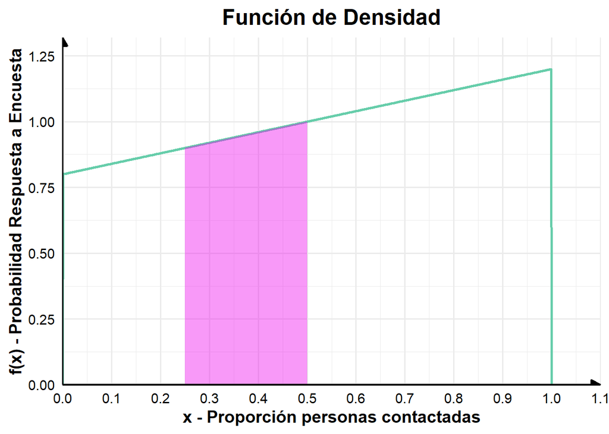

```
## b) La probabilidad de que más de 1/4 pero menos de 1/2 de las personas contactadas respondan a este tipo de encuesta es: 0.2375
```

## 2.2 Segundo punto

*Enunciado 3.15:* Calcule la función de distribución acumulativa de la variable aleatoria X que represente el número de unidades defectuosas en el ejercicio 3.11. Luego, utilice F(x) para calcular:

1. P(X = 1);
2. P(0 < X ≤ 2).

*Solución:*

Del total de 7 televisores, 2 están defectuosos y se compran 3 al azar, x es la cantidad de defectuosos que fueron comprados, x puede tener los valores de 0, 1 y 2, se calculan las probabilidades y se obtiene que la distribución de probabilidad es la siguiente:

```
##   x f.x.15
## 1 0  0.286
## 2 1  0.571
## 3 2  0.143
```

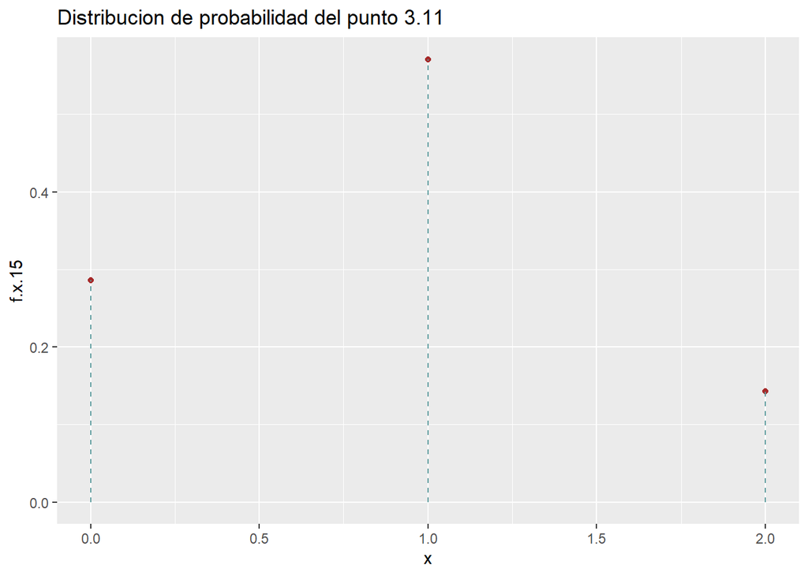

```
## a) La P (X = 1) es la misma f(1), que es:  0.571
```

La función de distribución acomulativa es:

$$F(x) =
\begin{cases}
0 & \text{si } x < 0 \\
\dfrac{2}{7} & \text{si } 0 \leq x < 1 \\
\dfrac{6}{7} & \text{si } 1 \leq x < 2 \\
1 & \text{si } x \geq 2
\end{cases}$$

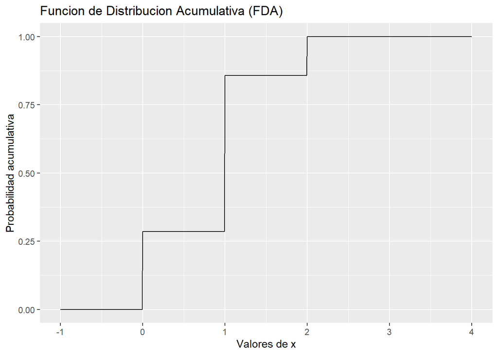

```
## b) La P(0 < X <= 2) se calcula como F(2) - F(0), se le resta F(0) porque solo queremos la probabilidad de que sea mayor a 0 y menor o igual a dos, y este valor es:  0.7142857
```

## 2.3 Tercer punto

*Enunciado 3.21:* Considere la función de densidad

$$f(x) =
\begin{cases}
k\sqrt{x}, & \text{si } 0 < x < 1, \\
0, & \text{en otro caso}.
\end{cases}$$

1. Evalúe k
2. Calcule F(x) y utilice el resultado para evaluar P(0.3 < X < 0.6).

*Solución:*
$$\int_0^1 k\sqrt{x} \, dx = 1 \\
k \int_0^1 x^{1/2} \, dx = k \cdot \left[ \frac{2}{3} x^{3/2}
\right]_0^1 \\
k \cdot \frac{2}{3} \cdot 1 = 1 \\
k \cdot \frac{2}{3} = 1 \Rightarrow k = \frac{3}{2}$$

```
## a) Para que f(x) sea una función de densidad. El valor de k es:  1.5
```

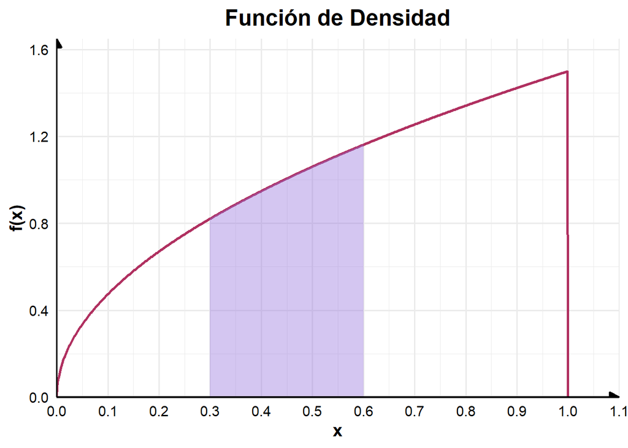

```
## b) La probabilidad P(0.3 < X < 0.6) para esta función, la cuál representa
## el área sombreada de la gráfica, es: 0.3004412
```

## 2.4 Cuarto punto

*Enunciado 3.27:* El tiempo que pasa, en horas, antes de que una parte importante de un equipo electrónico que se utiliza para fabricar un reproductor de DVD empiece a fallar tiene la siguiente función de densidad:

$$f(x) =
\begin{cases}
\frac{1}{2000} \exp\left(-\frac{x}{2000}\right), & x \geq 0, \\
0, & x < 0.
\end{cases}$$

1. Calcule F(x).
2. Determine la probabilidad de que el componente (y, por lo tanto, el reproductor de DVD) funcione durante más de 1000 horas antes de que sea necesario reemplazar el componente.
3. Determine la probabilidad de que el componente falle antes de 2000 horas.

*Solución:*

[output not shown]

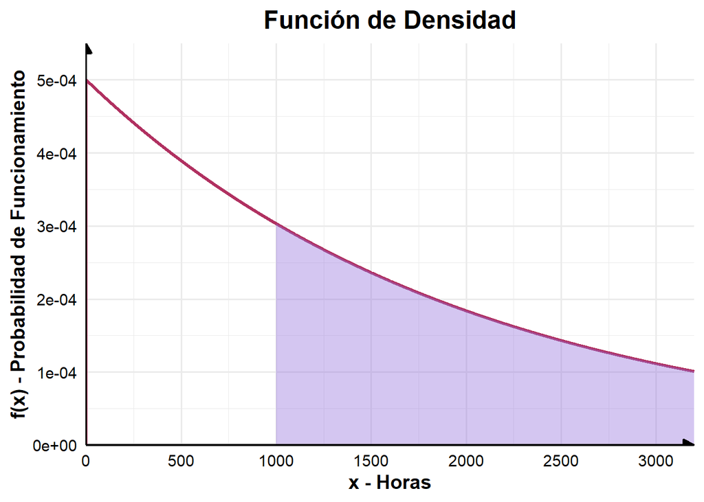

```
## b) La probabilidad de que el componente funcione más de 1000 horas es: 0.6065307
```

```
## c) La probabilidad de que el componente falle antes de cumplir 2000 horas es: 0.6321206
```

## 2.5 Quinto punto

*Enunciado 3.33:* Suponga que cierto tipo de pequeñas empresas de procesamiento dedatos están tan especializadas que algunas tienen dificultades para obtener utilidades durante su primer año de operación. La función de densidad de probabilidad que caracteriza la proporción Y que obtiene utilidades está dada por:

$$f(y) =
\begin{cases}
k y^4 (1 - y)^3, & 0 \leq y \leq 1, \\
0, & \text{en otro caso}.
\end{cases}$$

1. ¿Cuál es el valor de k que hace de la anterior una función de densidad válida?
2. Calcule la probabilidad de que al menos 50% de las empresas tenga utilidades durante el primer año.
3. Calcule la probabilidad de que al menos 80% de las empresas tenga utilidades durante el primer año.

*Solución:*
$$\int_0^1 k y^4 (1 - y)^3 \, dy = 1 \\
k \int_0^1 y^4 (1 - y)^3 \, dy = k \int_0^1 (-y^7 + 3y^6 - 3y^5 + y^4)
\, dy \\
= k \left( -\frac{1}{8} + \frac{3}{7} - \frac{1}{2} + \frac{1}{5}
\right) \\
= k \cdot \frac{1}{280} = 1 \\
\Rightarrow k = 280$$

```
## a) El valor de k que hace que f(x) sea una función de densidad válida es: 280
```

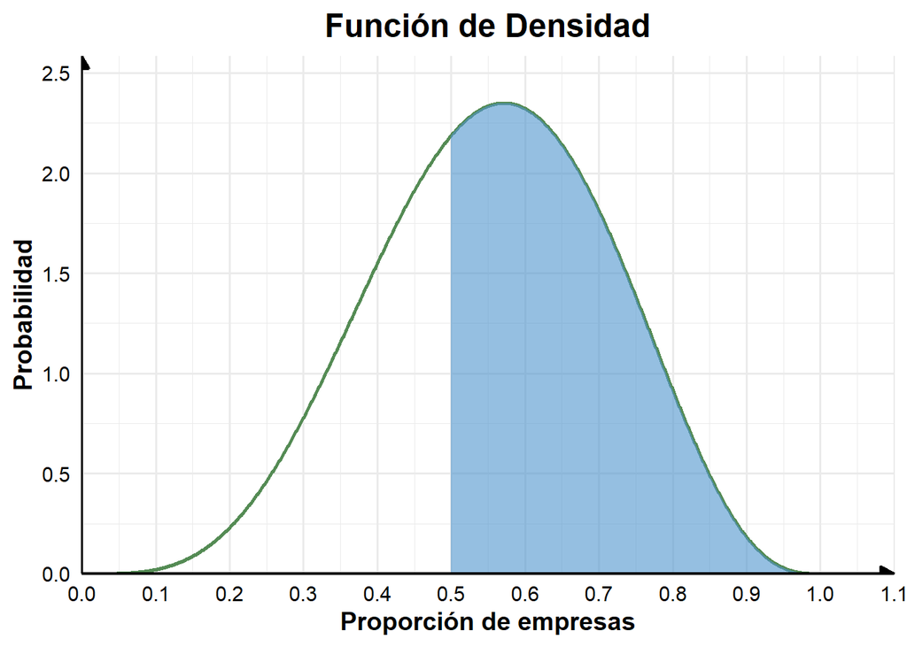

```
## b) La probabilidad de que al menos el 50% de las empresas tenga utilidades
## durante el primer año es: 0.6367188
```

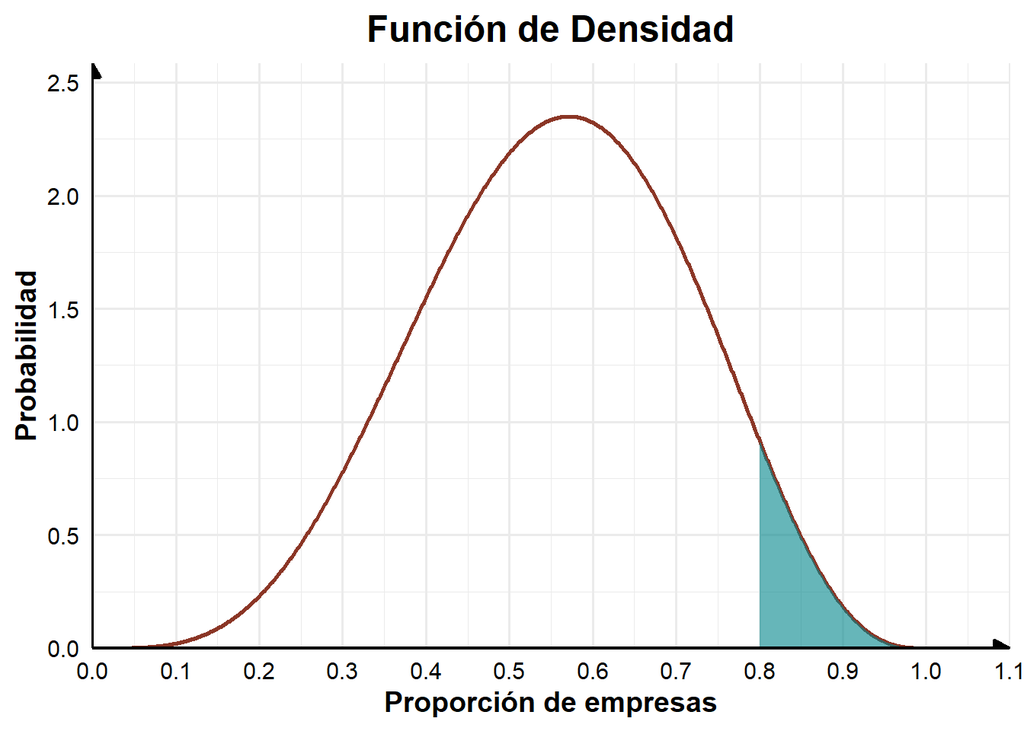

[output not shown]

# 3 Notas

La personalización de este trabajo, es decir, la modificación del tema **darkly** mediante el archivo *css* fue posible gracias al trabajo cooperativo con Chatgpt, junto con su ayuda explicando como crear y personalizar las gráficas y funciones.

# 4 Bibliografía

[Probabilidad y Estadística para Ingeniería y Ciencias (9a Edición)](https://bibliotecavirtualaserena.wordpress.com/wp-content/uploads/2017/05/libro_probabilidad-y-estadistica-para-ingenerc3ada-y-ciencias-ronald-e-walpole-mayers.pdf)